# Generalized Dissimilarity Modeling

> Mantel Test: a correlation between two dissimilarity matrices

First, let’s cover linear matrix regression with Mantel tests. A mantel statistic is simply a correlation between entries of two dissimilarity matrices.

Significance assessed by permutations of N rows and columns of a dissimilarity matrix. It permutes the rows and columns of the second matrix randomly and calculates a Z-statistic.

- Oribatid mite data: 70 soil cores (Borcard et al. 1992, 1994)
  - SubsDens: Substrate density (g/L)
  - WatrCont: Water content of the substrate (g/L)
  - Other categorical covariates

**Does mite community composition correlate with environmental parameters?**

```r
library(vegan)
```

```r
library(ggplot2)

# Read in mite data and environemental metadata
data(mite)
data(mite.env)

# Calculate dissimilarity matrices
comm.dist <- as.matrix(vegdist(mite)) # Bray-Curtis
env.dist <- as.matrix(vegdist(scale(mite.env[, 1:2]), "euclid")) # Euclidean; can only use continuous data

# Calculate mantel
mantel.pearson <- mantel(xdis = comm.dist, ydis = env.dist, method = "pearson", permutations = 999)
mantel.pearson
```

```
##
## Mantel statistic based on Pearson's product-moment correlation
##
## Call:
## mantel(xdis = comm.dist, ydis = env.dist, method = "pearson",      permutations = 999)
##
## Mantel statistic r: 0.4329
##       Significance: 0.001
##
## Upper quantiles of permutations (null model):
##    90%    95%  97.5%    99%
## 0.0742 0.0993 0.1199 0.1526
## Permutation: free
## Number of permutations: 999
```

```r
mantel.spearman <- mantel(xdis = comm.dist, ydis = env.dist, method = "spearman", permutations = 999)
mantel.spearman
```

```
##
## Mantel statistic based on Spearman's rank correlation rho
##
## Call:
## mantel(xdis = comm.dist, ydis = env.dist, method = "spearman",      permutations = 999)
##
## Mantel statistic r: 0.4361
##       Significance: 0.001
##
## Upper quantiles of permutations (null model):
##    90%    95%  97.5%    99%
## 0.0626 0.0806 0.1055 0.1310
## Permutation: free
## Number of permutations: 999
```

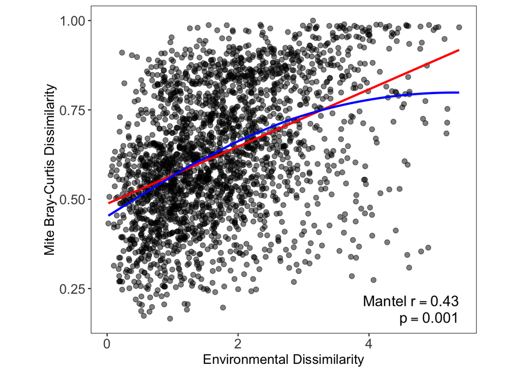

```r
# Subset upper.tri of distance matrix
comm.dist.mantel <- comm.dist[upper.tri(comm.dist)]
env.dist.mantel <- env.dist[upper.tri(env.dist)]
# Make data frame to plot
mantel.dat <- data.frame(Comm.Dist = comm.dist.mantel, Env.Dist = env.dist.mantel)

# Make mantel plots
ggplot(data = mantel.dat, aes(x = Env.Dist, y = Comm.Dist)) +
  geom_point(alpha = 0.5, size = 2) +
  stat_smooth(method = "lm", se = FALSE, colour = "red", formula = y ~ x) +
  stat_smooth(method = "loess", se = FALSE, colour = "blue", formula = y ~ x) +
  theme_bw() +
  theme(
    axis.text.x = element_text(size = 13),
    axis.text.y = element_text(size = 13),
    axis.title.x = element_text(size = 13),
    axis.title.y = element_text(size = 13),
    panel.grid.major = element_blank(),
    panel.grid.minor = element_blank(),
    panel.background = element_blank(),
    axis.line.x = element_blank(),
    axis.line.y = element_blank(),
    aspect.ratio = 0.85
  )  +
  labs(x = "Environmental Dissimilarity", y = "Mite Bray-Curtis Dissimilarity") +
  annotate(geom = "text", x = max(mantel.dat$Env.Dist), y = min(mantel.dat$Comm.Dist) * 1.3, label = paste("Mantel~r ==", signif(mantel.pearson$statistic, 2)), hjust = 1, parse = T, size = 5) +
  annotate(geom = "text", x = max(mantel.dat$Env.Dist), y = min(mantel.dat$Comm.Dist), label = paste("p ==", signif(mantel.pearson$signif, 2)), hjust = 1, parse = T, size = 5)
```

```r
# Mite community composition is significantly related to changes in substrate density and water content.

# But what if we wanted to account spatial autocorrelation?
```

- Partial Mantel statistic uses partial correlation conditioned on the third matrix:
  - Allows a comparison to be made among two variables while controlling for the third (e.g., aspect of experimental design)
  - The significance of the statistic is evaluated by permuting rows and columns of the first dissimilarity matrix (hence, order matters)
  - Recommended to only use pearson correlation for this test.
  - All are matrices of distance (or difference) measurements.

The function `mantel.partial` finds the partial matrix correlation between three dissimilarity matrices.

```r
# Read in spatial coordinates
data(mite.xy)

# Calculate dissimilarity matrix
spat.dist <- vegdist(mite.xy, "euclid")

mantel.partial(xdis = comm.dist, ydis = env.dist, zdis = spat.dist , method = "pearson", permutations = 999)
```

```
##
## Partial Mantel statistic based on Pearson's product-moment correlation
##
## Call:
## mantel.partial(xdis = comm.dist, ydis = env.dist, zdis = spat.dist,      method = "pearson", permutations = 999)
##
## Mantel statistic r: 0.3552
##       Significance: 0.001
##
## Upper quantiles of permutations (null model):
##    90%    95%  97.5%    99%
## 0.0765 0.0972 0.1242 0.1491
## Permutation: free
## Number of permutations: 999
```

```r
# Relationship between mite community composition and environment still remain significantly associated after controlling for spatial structure.
```

Sources:

```r
help("mantel")
help("mite")
# http://userwww.sfsu.edu/efc/classes/biol710/spatial/spatial.htm
```

> Generalized Dissimilarity Modeling: a statistical technique for modelling spatial variation in biodiversity between pairs of geographical locations.

GDM models biological variation as a function of environment and geography using distance matrices – specifically by relating dissimilarity in *species composition* between sites to their environmental conditions (*environmental distance*) and how isolated they are from one another (*geographical distance*).

### Four main steps to fitting GDMS

#### 1. Formatting biodiversity and environmental data to gdm’s site-pair format

#### 2. Fitting GDMs using geographic and environmental distances between sites

#### 3. Plotting fitted functions & extracting I-spline values

#### 4. Predicting pairwise dissimiliarites between sites or times and transforming envirnmental predictors to biological importance and mapping these patterns.

This example uses an x-y species list where there is one row per species record rather than per site. Other common input like site-by-species tables (sites in rows, species across columns) for the response and site-by-environment tables (sites in rows, predictors across columns) as the predictors are accommodated along with distance matrices and rasters.

```r
library(gdm)
# reads in example input data
load(system.file("./data/gdm.RData", package="gdm"))

# columns 3-7 are soils variables, remainder are climate
gdmExpData[1:3,]
```

|  | species | site | awcA | phTotal | sandA | shcA | solumDepth | bio5 | bio6 | bio15 | bio18 | bio19 | Lat | Long |
| --- | --- | --- | --- | --- | --- | --- | --- | --- | --- | --- | --- | --- | --- | --- |
| 1 | spp1 | 1066 | 14.4725 | 546.1800 | 71.3250 | 178.865 | 875.1725 | 31.43824 | 5.058823 | 40.38235 | 0 | 132.6471 | -32.99425 | 118.7573 |
| 2 | spp1 | 1026 | 16.2575 | 470.9950 | 68.8975 | 105.840 | 928.4925 | 33.14412 | 4.852941 | 48.20588 | 0 | 140.2941 | -32.04285 | 118.3495 |
| 3 | spp1 | 1025 | 23.1375 | 459.7425 | 71.4700 | 88.355 | 892.2275 | 32.84000 | 4.817143 | 53.88571 | 43 | 145.0571 | -31.99067 | 117.8260 |

```r
# get columns with xy, site ID, and species data
sppTab <- gdmExpData[, c("species", "site", "Lat", "Long")]

# get columns with env. data and xy-coordinates
envTab <- gdmExpData[, c(2:ncol(gdmExpData))]
```

- `formatsitepair`: To convert biodiversity and environmental data to site-pair format
- Goal: combine the biological and environmental data into “site-pair” format
  - Each row = biological distance measure in the first column (the default is Bray-Curtis distance)
  - Second column contains the weight to be assigned to each data point in model fitting (defaults to 1, but can be customized)
  - Remaining columns are the environmental values at a site (s1) and those at a second site (s2) making up a site pair.

```r
# x-y species list example
gdmTab <- formatsitepair(sppTab, bioFormat=2, XColumn="Long", YColumn="Lat", sppColumn="species", siteColumn="site", predData=envTab)
head(gdmTab)
```

|  | distance | weights | s1.xCoord | s1.yCoord | s2.xCoord | s2.yCoord | s1.awcA | s1.phTotal | s1.sandA | s1.shcA | s1.solumDepth | s1.bio5 | s1.bio6 | s1.bio15 | s1.bio18 | s1.bio19 | s2.awcA | s2.phTotal | s2.sandA | s2.shcA | s2.solumDepth | s2.bio5 | s2.bio6 | s2.bio15 | s2.bio18 | s2.bio19 |
| --- | --- | --- | --- | --- | --- | --- | --- | --- | --- | --- | --- | --- | --- | --- | --- | --- | --- | --- | --- | --- | --- | --- | --- | --- | --- | --- |
| 132 | 0.4485981 | 1 | 115.057 | -29.40472 | 115.5677 | -29.46599 | 23.0101 | 480.3266 | 83.99326 | 477.5656 | 1129.933 | 34.668 | 8.908 | 86.64 | 0 | 267.44 | 22.39250 | 494.1225 | 76.69000 | 357.7225 | 1183.9025 | 35.50571 | 7.448572 | 75.37143 | 0 | 228.6572 |
| 132.1 | 0.7575758 | 1 | 115.057 | -29.40472 | 116.0789 | -29.52556 | 23.0101 | 480.3266 | 83.99326 | 477.5656 | 1129.933 | 34.668 | 8.908 | 86.64 | 0 | 267.44 | 17.09750 | 415.1275 | 70.01750 | 112.4800 | 985.5300 | 36.05000 | 6.605882 | 64.52941 | 0 | 168.8824 |
| 132.2 | 0.8939394 | 1 | 115.057 | -29.40472 | 116.5907 | -29.58342 | 23.0101 | 480.3266 | 83.99326 | 477.5656 | 1129.933 | 34.668 | 8.908 | 86.64 | 0 | 267.44 | 17.03000 | 333.4400 | 71.59500 | 165.7250 | 956.5425 | 36.18750 | 6.131250 | 58.75000 | 0 | 141.1250 |
| 132.3 | 0.9178082 | 1 | 115.057 | -29.40472 | 117.1029 | -29.63957 | 23.0101 | 480.3266 | 83.99326 | 477.5656 | 1129.933 | 34.668 | 8.908 | 86.64 | 0 | 267.44 | 20.27750 | 411.4175 | 76.60250 | 185.1150 | 967.4150 | 36.04857 | 5.680000 | 54.51429 | 0 | 128.7429 |
| 132.4 | 0.9787234 | 1 | 115.057 | -29.40472 | 117.6156 | -29.69400 | 23.0101 | 480.3266 | 83.99326 | 477.5656 | 1129.933 | 34.668 | 8.908 | 86.64 | 0 | 267.44 | 14.27500 | 277.9775 | 62.86750 | 119.9950 | 705.0200 | 36.03030 | 5.409091 | 50.30303 | 0 | 118.0606 |
| 132.5 | 0.3519553 | 1 | 115.057 | -29.40472 | 114.9858 | -29.85145 | 23.0101 | 480.3266 | 83.99326 | 477.5656 | 1129.933 | 34.668 | 8.908 | 86.64 | 0 | 267.44 | 20.72444 | 482.8578 | 82.13778 | 369.2444 | 977.1778 | 33.81000 | 9.175000 | 85.45000 | 30 | 299.5000 |

- Dealing with biases associated with presence-only data
  - Ideal data are occurrence records (presence-absence or abundance) where all species have been intensively sampled
  - However, most species data are collected as part of ad hoc surveys and are presence-only (i.e., minimal confidence on species absence)
  - This leads to grid cells with occurrence records dependent on the number of species observed with many grid cells having none, a few, or even a single species record
  - *Under-sampled sites will lead to erroneously high values and will bias the model*
- The formatsitepair function provides a few options for dealing with this potential bias, including
  - 1. weighting sites relative to the number of species observed (weightType=“richness”),
  - 2. removing sites with few species (e.g., speciesFilter=10) or
  - 3. both

```r
# weight by site richness
gdmTab.rw <- formatsitepair(sppTab, bioFormat=2, XColumn="Long", YColumn="Lat", sppColumn="species", siteColumn="site", predData=envTab, weightType="richness")
# weights based on richness (number of species records)
gdmTab.rw$weights[1:5]
```

```
## [1] 0.2449866 0.1916207 0.1635852 0.1858930 0.1337957
```

```r
# remove sites with < 10 species records
gdmTab.sf <- formatsitepair(sppTab, bioFormat=2, XColumn="Long", YColumn="Lat", sppColumn="species", siteColumn="site", predData=envTab, sppFilter=10)
```

2. Model fitting and summary
   - `gdm` To fit a GDM model
   - `summary` To summarize a GDM model
- GDM is a nonlinear extension of permutational matrix regression that uses flexible splines and a GLM to accommodate two types of nonlinearity common in ecological datasets:
  - 1. variation in the rate of compositional turnover (non-stationarity) along environmental gradients, and
  - 2. the curvilinear relationship between biological distance and environmental and geographical distance.
- In addition to specifying whether or not the model should be fit with geographical distance as a predictor variable, the user can also specify
  - 1. the number of I-spline basis functions (the default is three, with larger values producing more complex splines) and
  - 2. the locations of “knots” along the splines (defaults 0 (minimum), 50 (median), and 100 (maximum) quantiles when three I-spline basis functions are used).
  - *The effects of altering the number of splines and knot locations has not been systematically explored.*

```r
gdm.1 <- gdm(gdmTab, geo=TRUE)

# The summary function provides an overview of the model, including deviance explained and the values of the coefficients for the I-spline for each predictor variable. Variables with all coefficients=0 have no relationship with the biological pattern. A shorter summary can be obtained using str.

summary(gdm.1)
```

```
## [1]
## [1]
## [1] GDM Modelling Summary
## [1] Creation Date:  Tue Sep  8 10:19:48 2020
## [1]
## [1] Name:  gdm.1
## [1]
## [1] Data:  gdmTab
## [1]
## [1] Samples:  4371
## [1]
## [1] Geographical distance used in model fitting?  TRUE
## [1]
## [1] NULL Deviance:  651.914444821758
## [1] GDM Deviance:  129.025463058706
```

[output cut: 103 more lines]

```r
str(gdm.1)
```

```
## List of 15
##  $ dataname    : symbol gdmTab
##  $ geo         : logi TRUE
##  $ sample      : int 4371
##  $ gdmdeviance : num 129
##  $ nulldeviance: num 652
##  $ explained   : num 80.2
##  $ intercept   : num 0.277
##  $ predictors  : chr [1:11] "Geographic" "awcA" "phTotal" "sandA" ...
##  $ coefficients: num [1:33] 0.014 0.372 0 0 0 ...
##  $ knots       : num [1:33] 0.452 2.46 6.532 12.975 22.186 ...
##  $ splines     : num [1:11] 3 3 3 3 3 3 3 3 3 3 ...
##  $ creationdate: chr "Tue Sep  8 10:19:48 2020"
##  $ observed    : num [1:4371] 0.449 0.758 0.894 0.918 0.979 ...
##  $ predicted   : num [1:4371] 0.472 0.713 0.871 0.853 0.978 ...
##  $ ecological  : num [1:4371] 0.639 1.25 2.048 1.921 3.804 ...
##  - attr(*, "class")= chr [1:2] "gdm" "list"
```

`plot` is used to plot the I-splines and fit of a generalized dissimilarity model created using the gdm function

The fitted splines represent one of the most informative outputs from gdm, which also can be used to transform and map environmental variables such that they best represent biological patterns.

- The fitted model and I-splines can be viewed using the plot function, which produces a multi-panel plot that includes:
  - 1. the fitted relationship between predicted ecological distance and observed compositional dissimilarity;
  - 2. predicted versus observed biological distance, and
  - 3. each I-spline with at least one non-zero coefficient

*The maximum height of each spline indicates the magnitude of total biological change along that gradient and thereby corresponds to the relative importance of that predictor in contributing to biological turnover while holding all other variables constant (i.e., is a partial ecological distance).*

*The spline’s shape indicates how the rate of biological change varies with position along that gradient. Thus, the splines provide insight into the total magnitude of biological change as a function of each gradient and where along each gradient those changes are most pronounced.*

In this example, compositional turnover is greatest along gradients of bio19 (winter precipitation) and phTotal (soil phosphorus) and most rapid near the low ends of these gradients.

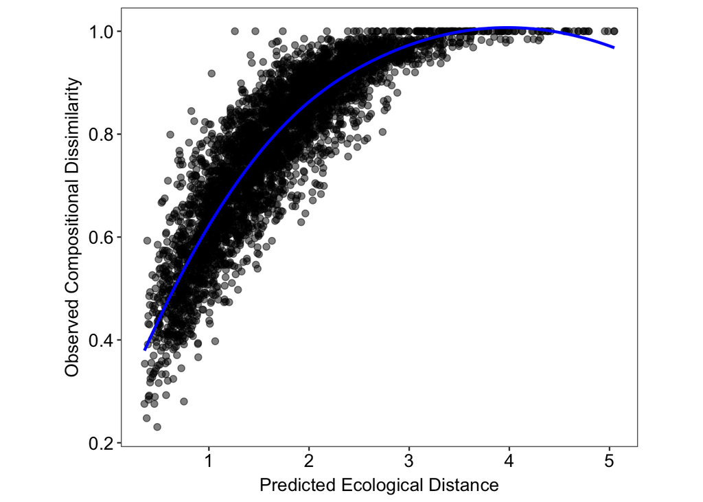

```r
# not run but this line gives you all plots
# plot(gdm.1, plot.layout=c(4,3))

# compositional dissimilarity vs. ecological distance
ggplot(data = NULL, aes(y = gdm.1$observed, x = gdm.1$ecological)) +
  geom_point(alpha = 0.5, size = 2) +
  stat_smooth(method = "loess", se = FALSE, colour = "blue", formula = y ~ x) +
  theme_bw() +
  theme(
    axis.text.x = element_text(size = 13, color = "black"),
    axis.text.y = element_text(size = 13, color = "black"),
    axis.title.x = element_text(size = 13, margin = margin(t = 5, r = 0, b = 0, l = 0)),
    axis.title.y = element_text(size = 13, margin = margin(t = 0, r = 5, b = 0, l = 0)),
    panel.grid.major = element_blank(),
    panel.grid.minor = element_blank(),
    panel.background = element_blank(),
    axis.line.x = element_blank(),
    axis.line.y = element_blank(),
    aspect.ratio = 0.85
  )  +
  labs(y = "Observed Compositional Dissimilarity", x = "Predicted Ecological Distance")
```

```r
# The plot of observed compositional dissimilarity (dij) vs. the linear predictor (ηij), indicates the fit between observed and predicted dissimilarity (the latter is represented by the curved line, which is the inverse-link function of the model). We refer to the linear-predictor axis of this plot as ‘predicted ecological distance'

gdm.1.splineDat <- isplineExtract(gdm.1)
str(gdm.1.splineDat)
```

```
## List of 2
##  $ x: num [1:200, 1:11] 0.452 0.483 0.513 0.544 0.574 ...
##   ..- attr(*, "dimnames")=List of 2
##   .. ..$ : NULL
##   .. ..$ : chr [1:11] "Geographic" "awcA" "phTotal" "sandA" ...
##  $ y: num [1:200, 1:11] 0 0.00045 0.00095 0.0015 0.0021 ...
##   ..- attr(*, "dimnames")=List of 2
##   .. ..$ : NULL
##   .. ..$ : chr [1:11] "Geographic" "awcA" "phTotal" "sandA" ...
```

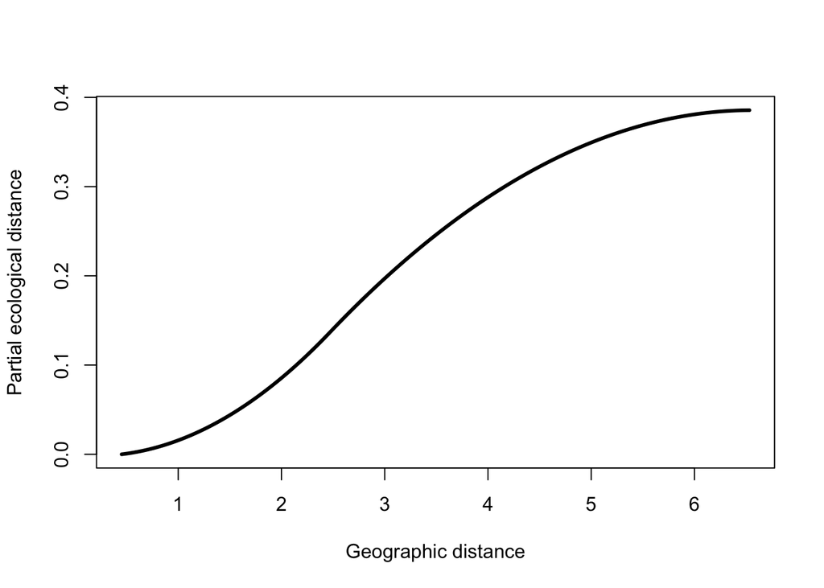

```r
plot(gdm.1.splineDat$x[,"Geographic"], gdm.1.splineDat$y[,"Geographic"], lwd=3, type="l", xlab="Geographic distance", ylab="Partial ecological distance")
```

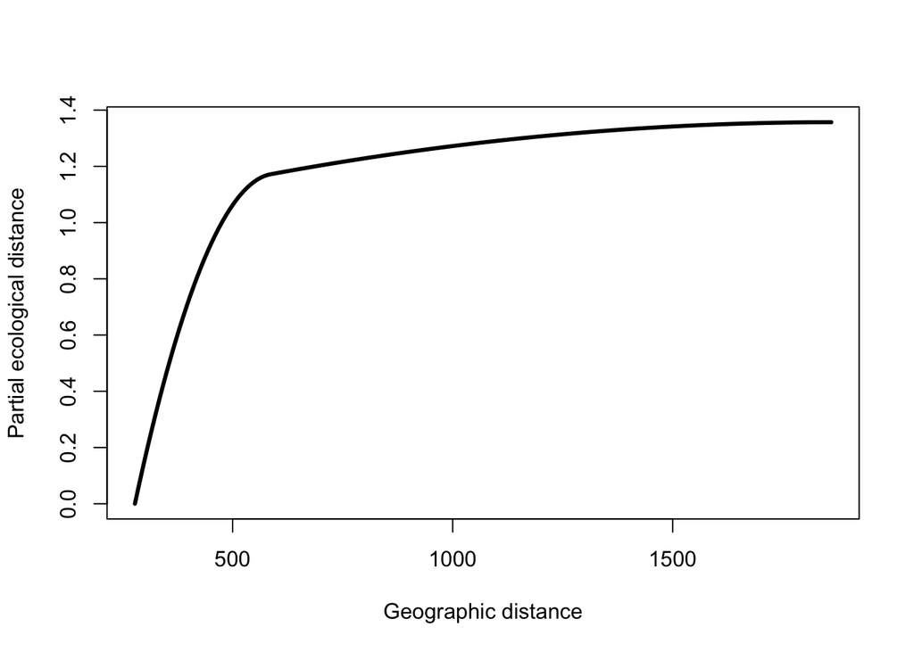

```r
plot(gdm.1.splineDat$x[,"phTotal"], gdm.1.splineDat$y[,"phTotal"], lwd=3, type="l", xlab="Geographic distance", ylab="Partial ecological distance")
```

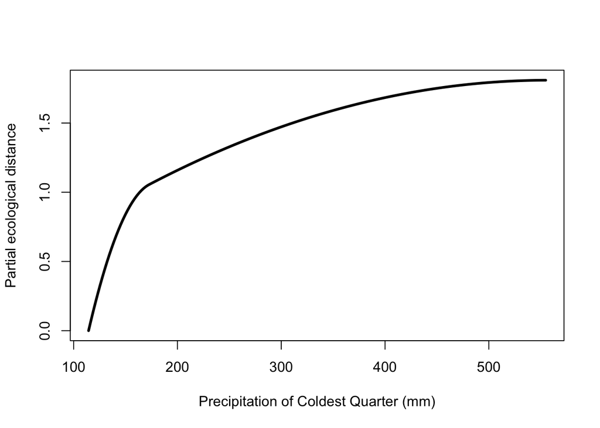

```r
plot(gdm.1.splineDat$x[,"bio19"], gdm.1.splineDat$y[,"bio19"], lwd=3, type="l", xlab="Precipitation of Coldest Quarter (mm)", ylab="Partial ecological distance")
```

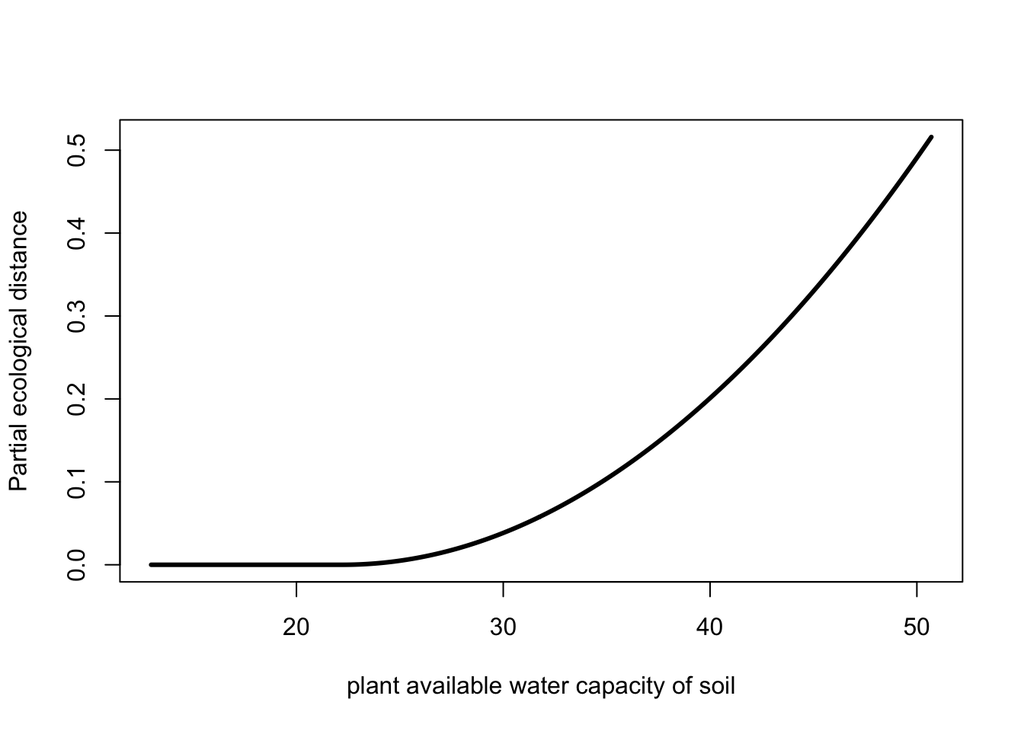

```r
plot(gdm.1.splineDat$x[,"awcA"], gdm.1.splineDat$y[,"awcA"], lwd=3, type="l", xlab="plant available water capacity of soil", ylab="Partial ecological distance")
```

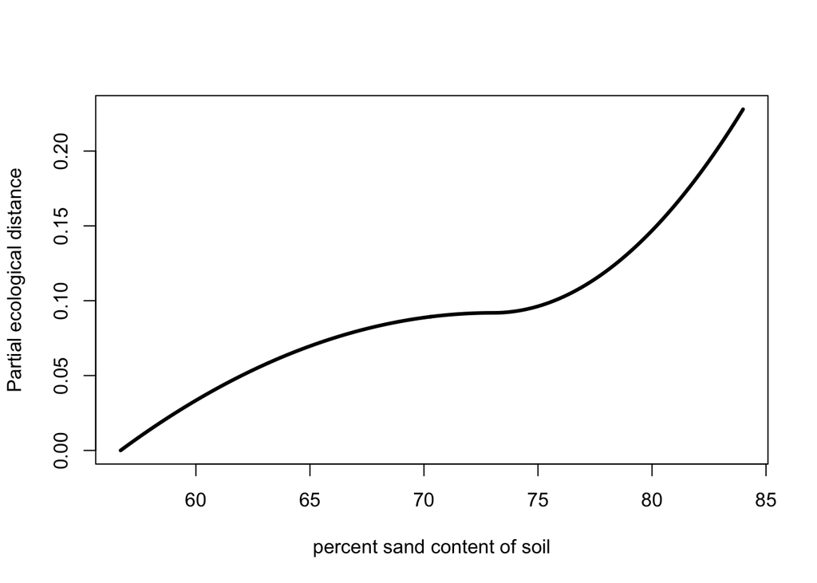

```r
plot(gdm.1.splineDat$x[,"sandA"], gdm.1.splineDat$y[,"sandA"], lwd=3, type="l", xlab="percent sand content of soil", ylab="Partial ecological distance")
```

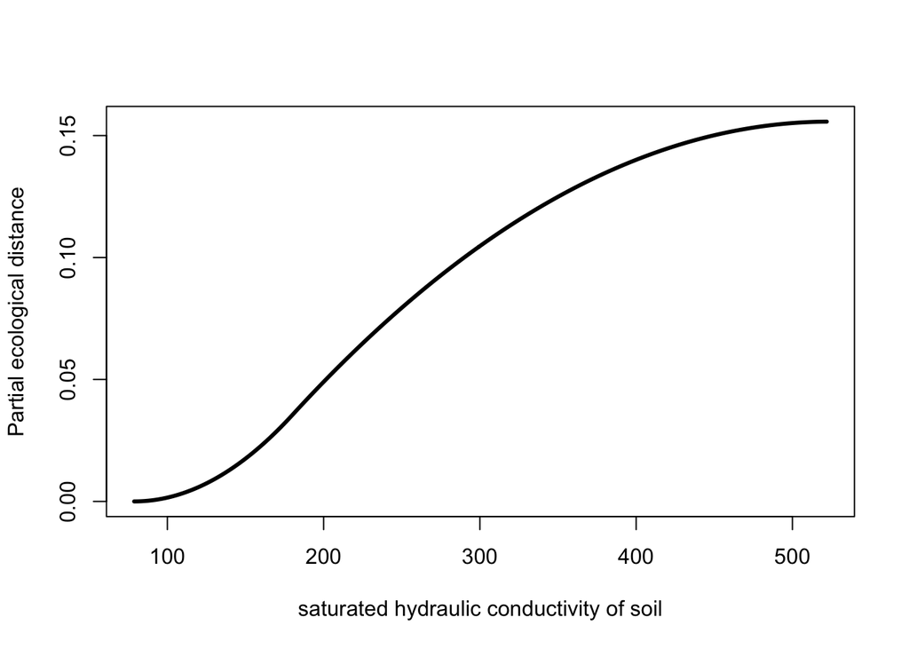

```r
plot(gdm.1.splineDat$x[,"shcA"], gdm.1.splineDat$y[,"shcA"], lwd=3, type="l", xlab="saturated hydraulic conductivity of soil", ylab="Partial ecological distance")
```

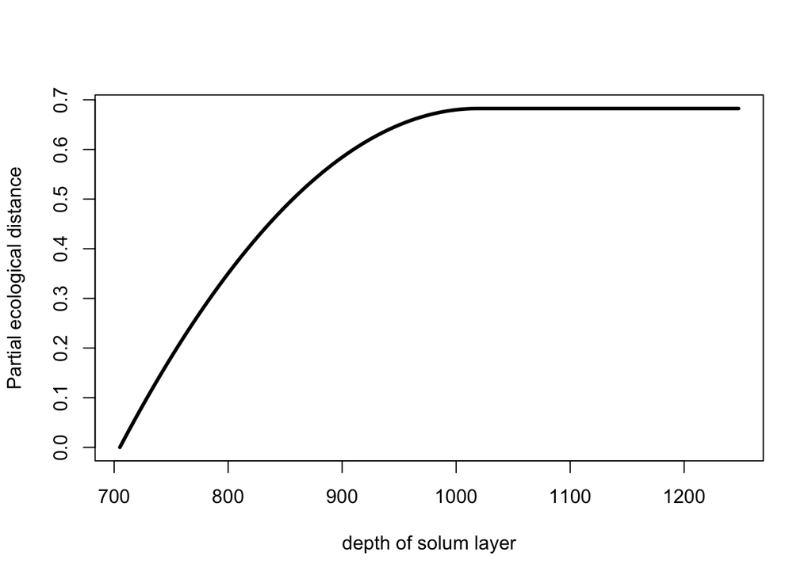

```r
plot(gdm.1.splineDat$x[,"solumDepth"], gdm.1.splineDat$y[,"solumDepth"], lwd=3, type="l", xlab="depth of solum layer", ylab="Partial ecological distance")
```

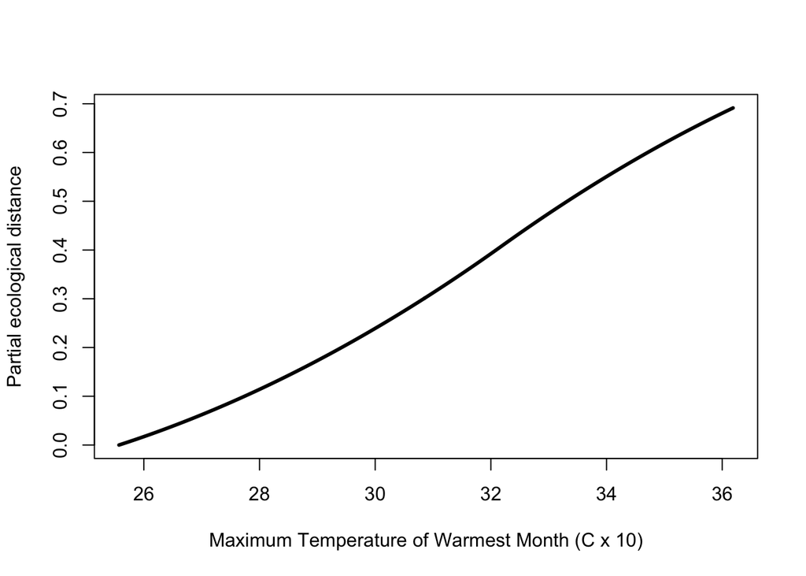

```r
plot(gdm.1.splineDat$x[,"bio5"], gdm.1.splineDat$y[,"bio5"], lwd=3, type="l", xlab="Maximum Temperature of Warmest Month (C x 10)", ylab="Partial ecological distance")
```

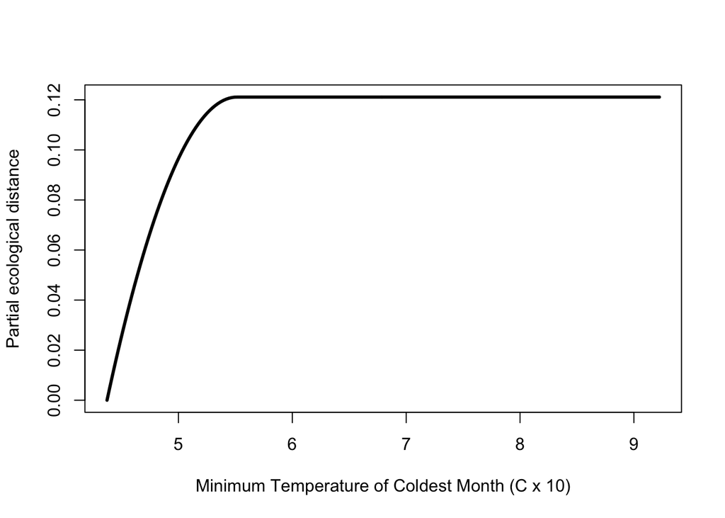

```r
plot(gdm.1.splineDat$x[,"bio6"], gdm.1.splineDat$y[,"bio6"], lwd=3, type="l", xlab="Minimum Temperature of Coldest Month (C x 10)", ylab="Partial ecological distance")
```

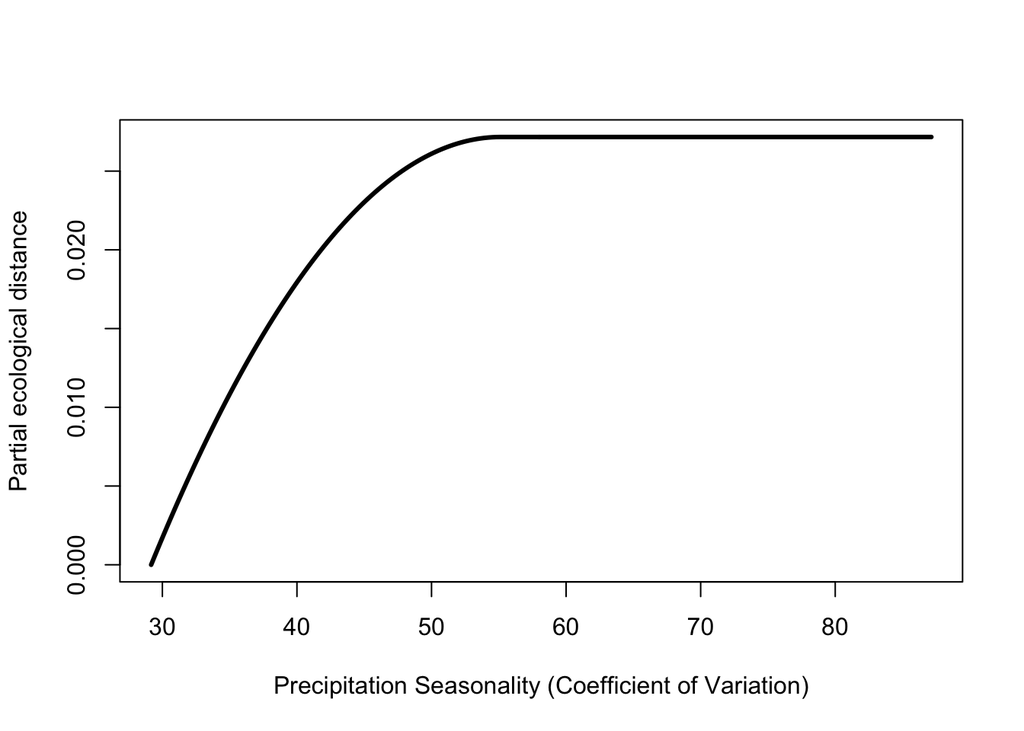

```r
plot(gdm.1.splineDat$x[,"bio15"], gdm.1.splineDat$y[,"bio15"], lwd=3, type="l", xlab="Precipitation Seasonality (Coefficient of Variation)", ylab="Partial ecological distance")
```

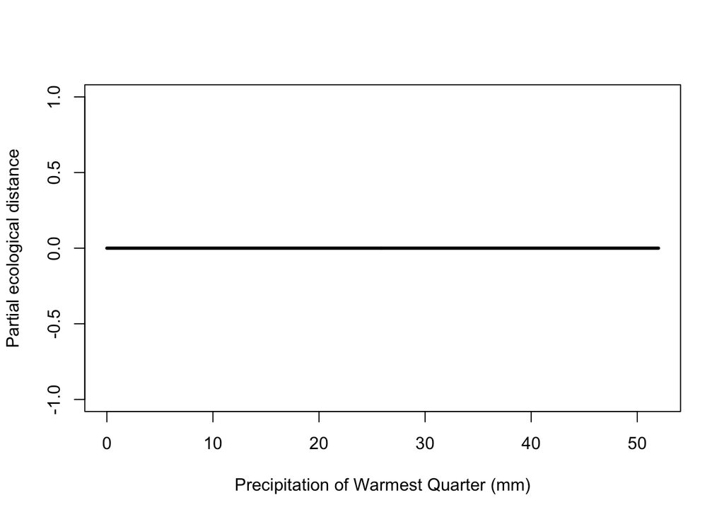

```r
plot(gdm.1.splineDat$x[,"bio18"], gdm.1.splineDat$y[,"bio18"], lwd=3, type="l", xlab="Precipitation of Warmest Quarter (mm)", ylab="Partial ecological distance")
```

```r
# Not run: Quantify model significance and variable importance/significance in gdm using matrix permutation
# modTest <- gdm.varImp(gdmTab, geo=TRUE, nPerm=50)
# barplot(sort(modTest[[2]][,1], decreasing=T))
```

```r
gdm.1.pred <- predict(gdm.1, gdmTab)
head(gdm.1.pred)
```

```
## [1] 0.4720423 0.7133571 0.8710175 0.8534788 0.9777208 0.3996694
```

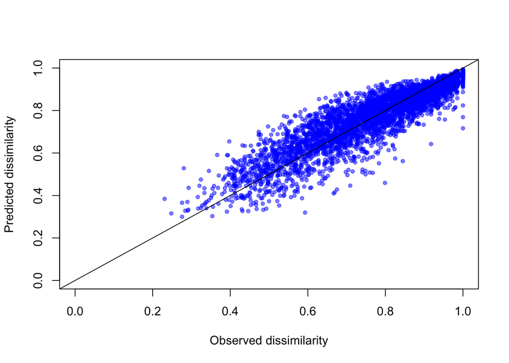

```r
par(mfrow = c(1,1))

plot(gdmTab$distance, gdm.1.pred, xlab="Observed dissimilarity", ylab="Predicted dissimilarity", xlim=c(0,1), ylim=c(0,1), pch=20, col=rgb(0,0,1,0.5))
lines(c(-1,2), c(-1,2))
```

```r
## Interpretation (from Sophia): First, recall that the dissimilarity matrix is our response "matrix" (actually vectorized like you would process an image, but all the same) so that is what we are fitting too. Our explanatory variables are values at each site that are derived from a linear combination of I-splines that are fit over the whole scope of the data. (So each explanatory variable x has some number of I-spline (m) that are combined in some fashion and evaluated at site i or j position.) So we are actually working with values that are derived from i-spline functions not another dissimilarity matrix. What we predict (our fitted values) from those variables is a fitted dissimilarity matrix. The relationship between fitted dissimilarity and the observed dissimilarity is what is displayed in that second graph. It's "strictly linear" because, ideally, we want every observed value of 0.2 to have a fitted value of 0.2 and we don't want our fit to be systematically off. (Also matrix regression/GLM requires linearity at some point (usually systematic component).
```

Transforming predictors and visualizing biological patterns

```r
# reordering environmental data to create table for transformation
envTrans <- envTab[, c(13,12,2:11)] # same order as gdmTab
envTrans[1:3,]
```

|  | Long | Lat | awcA | phTotal | sandA | shcA | solumDepth | bio5 | bio6 | bio15 | bio18 | bio19 |
| --- | --- | --- | --- | --- | --- | --- | --- | --- | --- | --- | --- | --- |
| 1 | 118.7573 | -32.99425 | 14.4725 | 546.1800 | 71.3250 | 178.865 | 875.1725 | 31.43824 | 5.058823 | 40.38235 | 0 | 132.6471 |
| 2 | 118.3495 | -32.04285 | 16.2575 | 470.9950 | 68.8975 | 105.840 | 928.4925 | 33.14412 | 4.852941 | 48.20588 | 0 | 140.2941 |
| 3 | 117.8260 | -31.99067 | 23.1375 | 459.7425 | 71.4700 | 88.355 | 892.2275 | 32.84000 | 4.817143 | 53.88571 | 43 | 145.0571 |

```r
# transform variables
tabTrans <- gdm.transform(gdm.1, envTrans)
tabTrans[1:3,]
```

```
##           Long       Lat         awcA   phTotal      sandA         shcA
## [1,] 0.2226638 0.1036539 0.0000000000 1.1437240 0.09098455 0.0349996799
## [2,] 0.1985913 0.1598227 0.0000000000 0.9902375 0.08618790 0.0025608921
## [3,] 0.1676795 0.1629031 0.0005822033 0.9560643 0.09114130 0.0003213945
##      solumDepth      bio5       bio6      bio15 bio18     bio19
## [1,]  0.5407158 0.3488653 0.10210250 0.01846392     0 0.5102596
## [2,]  0.6269481 0.4892084 0.08073046 0.02528373     0 0.6754013
## [3,]  0.5726173 0.4650542 0.07620206 0.02711470     0 0.7637484
```

```r
# environmental raster data
rastFile <- system.file("./extdata/stackedVars.grd", package="gdm")
envRast <- stack(rastFile)
gdmTab.rast <- formatsitepair(sppTab, bioFormat=2, XColumn="Long", YColumn="Lat",
sppColumn="species", siteColumn="site", predData=envRast)
```

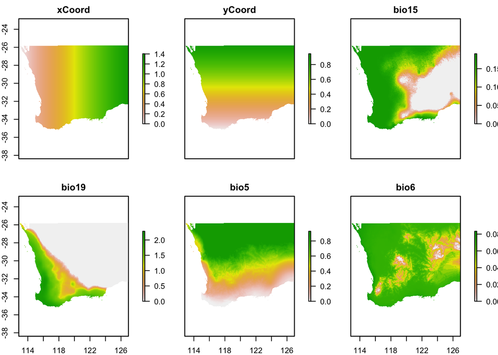

```r
# remove NA values
gdmTab.rast <- na.omit(gdmTab.rast)

# fit a new gdm using a table with climate data only (to match rasters)
gdm.rast <- gdm(gdmTab.rast, geo=TRUE)

# transform climate rasters & plot pattern
rastTrans <- gdm.transform(gdm.rast, envRast)
plot(rastTrans)
```

Visualizing multi-dimensional biological patterns

Pairwise site biological distances are difficult to visualize. However, if the transform function is applied to rasters, the resulting multi-dimensional biological space can be mapped to reveal biological patterns in geographic space.

Alternatively, a biplot can be used to depict where sites fall relative to each other in biological space and therefore how sites differ in predicted biological composition.

In either case, the multi-dimensional biological space can be most effectively visualized by taking a PCA to reduce dimensionality and assigning the first three components to an RGB color palette.

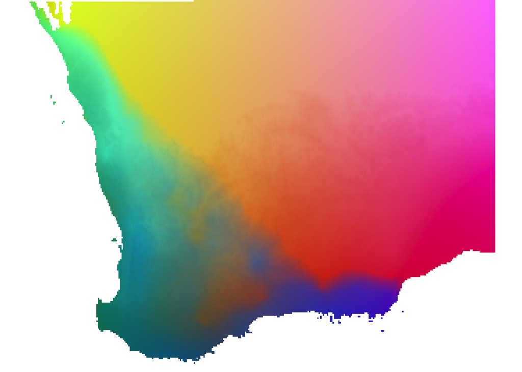

```r
rastDat <- na.omit(getValues(rastTrans))

pcaSamp <- prcomp(rastDat)

# note the use of the 'index' argument
pcaRast <- predict(rastTrans, pcaSamp, index=1:3)

# scale rasters
pcaRast[[1]] <- (pcaRast[[1]]-pcaRast[[1]]@data@min) /
(pcaRast[[1]]@data@max-pcaRast[[1]]@data@min)*255
pcaRast[[2]] <- (pcaRast[[2]]-pcaRast[[2]]@data@min) /
(pcaRast[[2]]@data@max-pcaRast[[2]]@data@min)*255
pcaRast[[3]] <- (pcaRast[[3]]-pcaRast[[3]]@data@min) /
(pcaRast[[3]]@data@max-pcaRast[[3]]@data@min)*255
plotRGB(pcaRast, r=1, g=2, b=3)
```

```r
# Predicted spatial variation in plant species composition. Colors represent gradients in species composition derived from transformed environmental predictors. Locations with similar colors are expected to contain similar plant communities.
```

Sources: https://cran.r-project.org/web/packages/gdm/vignettes/gdmVignette.pdf https://cran.r-project.org/web/packages/gdm/gdm.pdf